# Women’s Diverse Travel Needs Often Go Overlooked

[figure not shown]

## The Puget Sound Regional Council Household Travel Survey provides data on travel by women

## Travel demands put different pressures on women

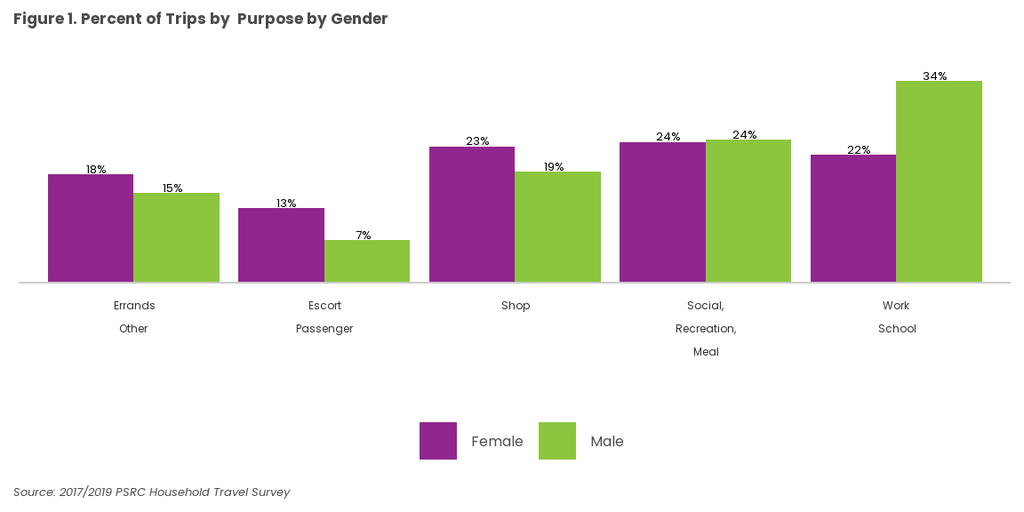

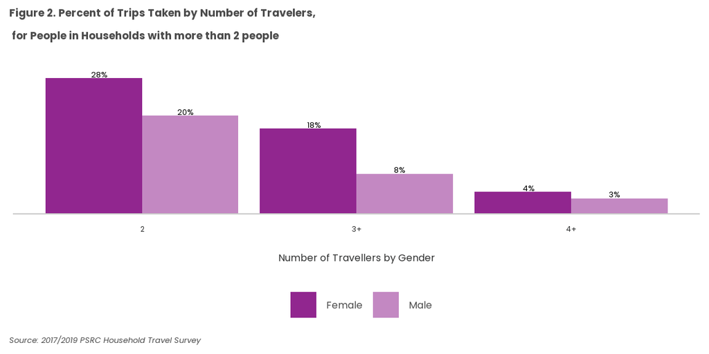

## Gender and race intersect in transportation needs

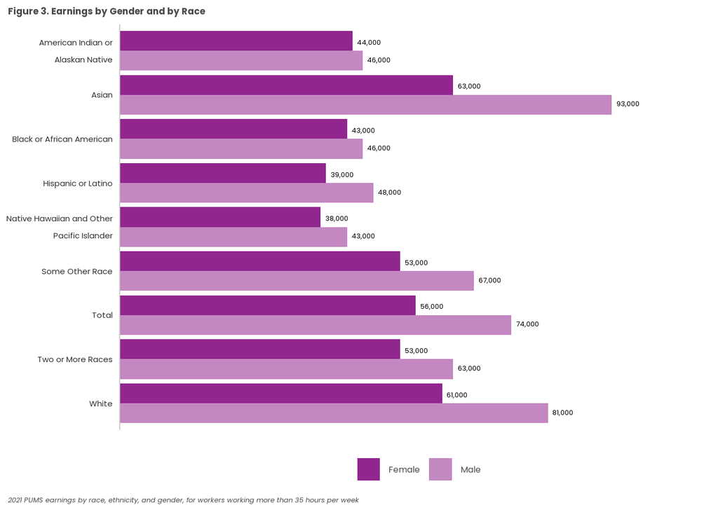

## Women of color use transit most

Women of color in the region used transit on more of their trips than men and white, non-Hispanic women-prior to COVID-19- as shown in Figure 4. Women of color used transit on nearly double the share of their trips as compared to white, non-Hispanic women. Women of color most likely used transit more than white, non-Hispanic women because of having lower incomes, fewer autos, and living in more transit-friendly areas, but more data is needed to confirm this hypothesis.

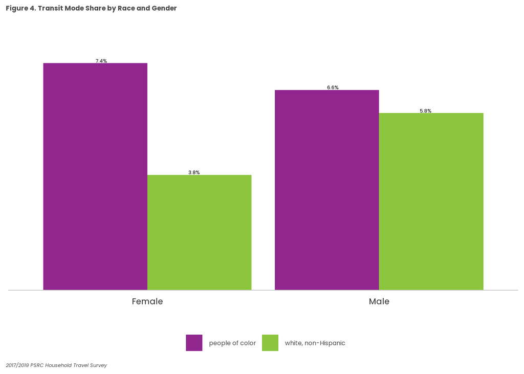

## Women bike far less than men

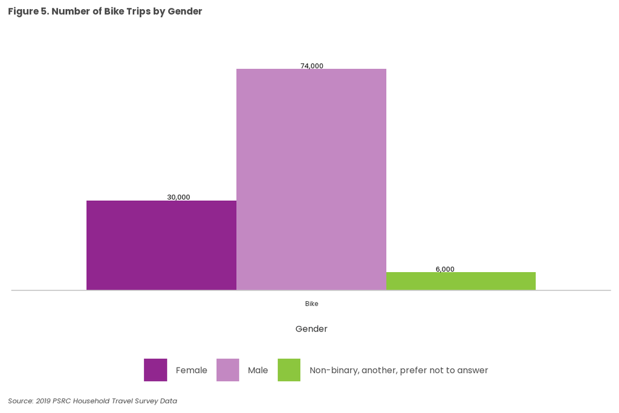

## Regional and nationwide data show similar constraints

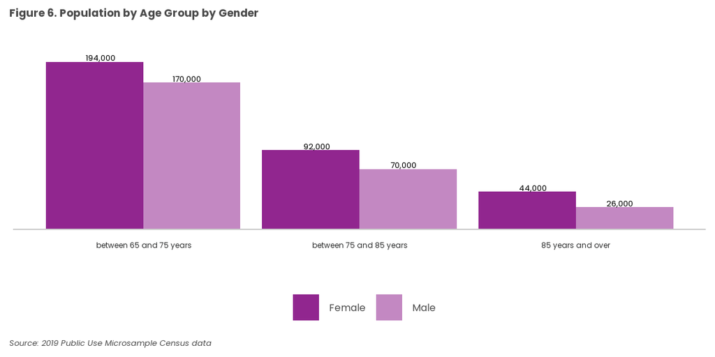

## Changes brought about by COVID-19 pandemic

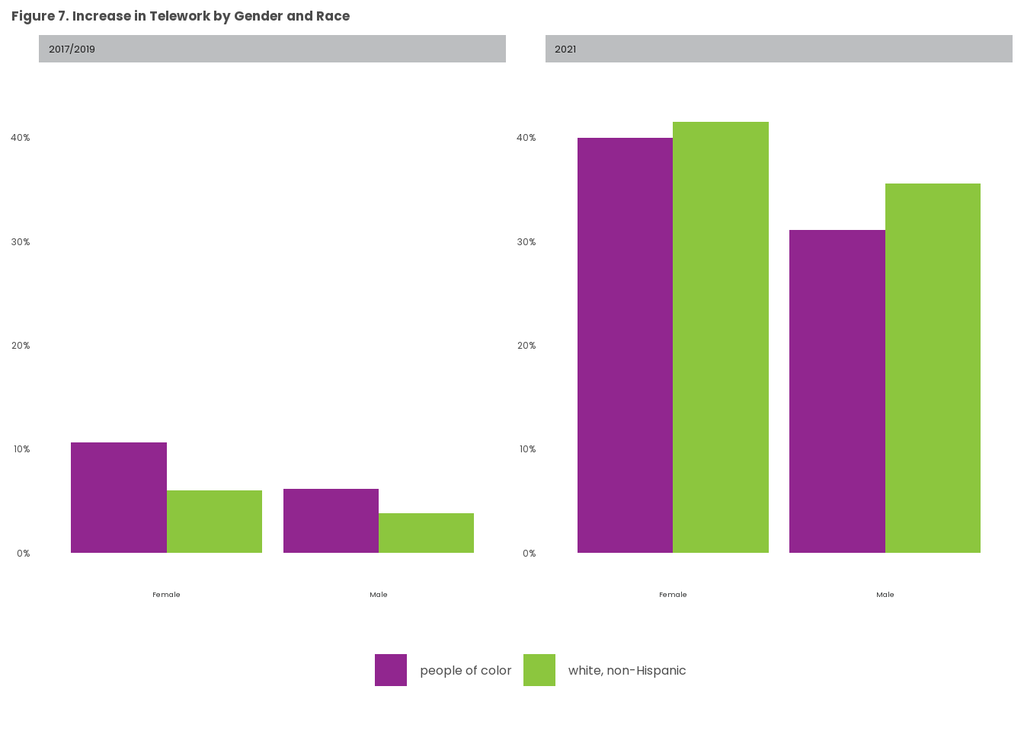

## Women of color continued to use transit more during COVID-19

Post-COVID-19, people of color continued to use transit more than white, non-Hispanic people. Women of color were still more likely than white, non-Hispanic women to ride transit. Most likely the women of color who still used transit lacked other options, but more investigation is needed. The largest drop in transit mode shares were for white, non-Hispanic men.

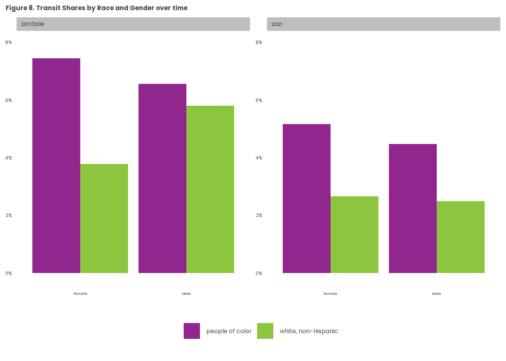

## Trip purposes by gender changed from 2017/2019 to 2021

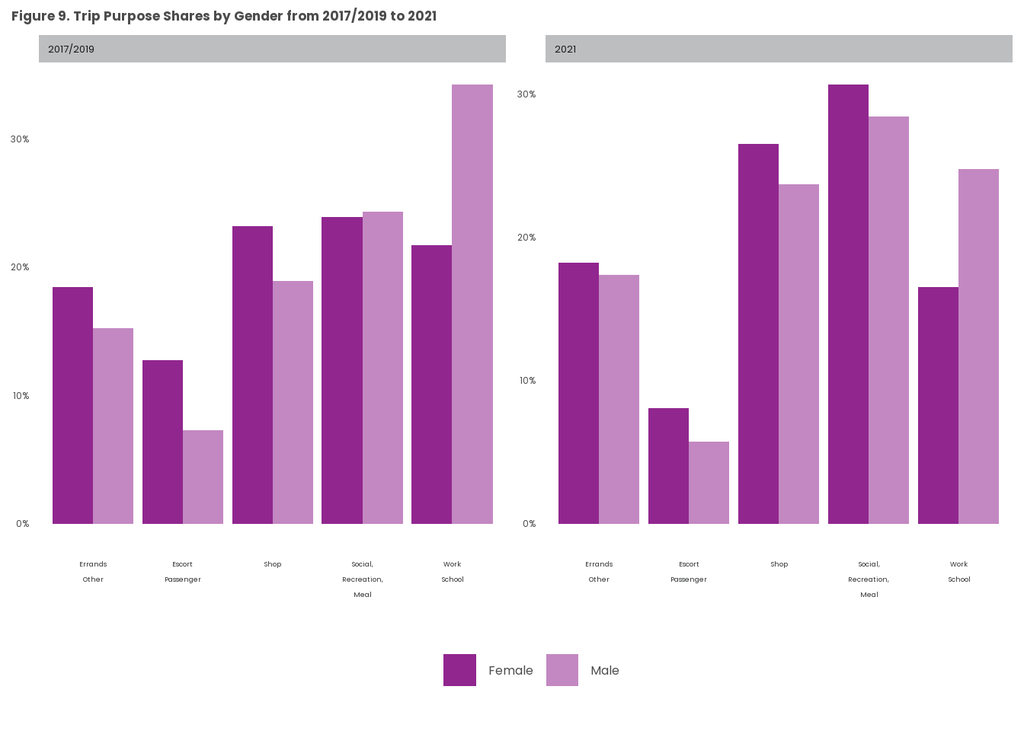